# Première manipulation avec R

PC

2021

# 1 Hello World

La fonction `print` affiche une chaîne de caractère ou une valeur numérique passé en argument

```r
print("Hello World!")
```

```
## [1] "Hello World!"
```

La fonction `cat` permet d’afficher plusieurs éléments , séparés par des virgules

```r
cat("Hello", "World", "!")
```

```
## Hello World !
```

`cat` accepte des éléments de type différent. Ici , une chaîne de caractère, un nombre, le résultat d’une fonction et un booléen :

```r
cat("abc", 12.3, sqrt(49), TRUE)
```

```
## abc 12.3 7 TRUE
```

# 2 Installer et charger des librairies

L’installation et le chargement des packages au moyen des fonctions `install.packages("nom_du_package")` et `library(nom_du_package)`

```r
install.packages("dplyr")
library(dplyr)
```

Le package `dplyr` est très utile, reportez vous à la cheat-sheet (ici en français) [https://thinkr.fr/pdf/dplyr-french-cheatsheet.pdf] pour en avoir un résumé des fonctions.

```r
install.packages("plamerpenguins")
library(palmerpenguins)
# aperçu des premières lignes du dataset
head(penguins)
```

```
## # A tibble: 6 × 8
##   species island bill_length_mm bill_depth_mm flipper_length_… body_mass_g sex
##   <fct>   <fct>           <dbl>         <dbl>            <int>       <int> <fct>
## 1 Adelie  Torge…           39.1          18.7              181        3750 male
## 2 Adelie  Torge…           39.5          17.4              186        3800 fema…
## 3 Adelie  Torge…           40.3          18                195        3250 fema…
## 4 Adelie  Torge…           NA            NA                 NA          NA <NA>
## 5 Adelie  Torge…           36.7          19.3              193        3450 fema…
## 6 Adelie  Torge…           39.3          20.6              190        3650 male
## # … with 1 more variable: year <int>
```

# 3 Déclarer une variable

Une variable se déclare avec l’opérateur `<-` (recommandé) ou `=` . Écrire le nom de la variable sur une ligne puis l’éxécuter renvoie la valeur courante de la variable. Si la ligne contient une opération ou l’appel d’une fonction, le résultat est affiché dans la console.

```r
a <-  5
a
```

```
## [1] 5
```

```r
a + 10
```

```
## [1] 15
```

## 3.1 Types primitifs

Les types primitifs en R sont : `numeric` , `character` (string) , `logical` (booléen), et `factor`

Voici des exemples d’instantiation:

```r
nunu <-  12.5
chacha <-  "Lorem Ipsum"
lolo <-  FALSE
fafa <-  factor(c("riri", "fifi", "loulou"))
```

# 4 Vecteur

La fonction `vector` permet d’initialiser un vecteur d’une certaine longueur et d’un certain type atomique (`numeric`, `logical` , ou `character`)

```r
veve <- vector(mode="numeric", length= 10 )
veve
```

```
##  [1] 0 0 0 0 0 0 0 0 0 0
```

Les opérations classiques appliquées à un vecteur sont «vectorisées», c’est-à-dire qu’elles sont appliquées terme à terme au vecteur .

```r
veve + 15
```

```
##  [1] 15 15 15 15 15 15 15 15 15 15
```

On peut également utiliser la fonction `c()` pour créer des collections en combinant des objets. Lorsqu’ils sont de type identique cela produit un vecteur

```r
coco <-  c(10,20,30,40,50,60,70,80,90)
coco
```

```
## [1] 10 20 30 40 50 60 70 80 90
```

## 4.1 Modifier un élément

Connaissant son index (= sa position dans le vecteur), la modification de la valeur d’un élément se fait à l’aide de l’opérateur d’affectation :

```r
coco
```

```
## [1] 10 20 30 40 50 60 70 80 90
```

```r
coco[5] <-  10000
coco
```

```
## [1]    10    20    30    40 10000    60    70    80    90
```

## 4.2 Ajouter une élément

On peut ajouter un élément à la fin d’un vecteur avec la fonction `c()` qui combine une valeur avec un objet et renvoie un élément de même type que l’objet combiné (ici : un vecteur)

```r
c(coco, "3.1416")
```

```
##  [1] "10"     "20"     "30"     "40"     "10000"  "60"     "70"     "80"
##  [9] "90"     "3.1416"
```

## 4.3 Supprimer un élément

Supprimer un élément d’un vecteur se fait d’un façon particulière : en excluant l’élément avec un signe “moins” devant son index.

```r
coco
```

```
## [1]    10    20    30    40 10000    60    70    80    90
```

```r
coco[-5]
```

```
## [1] 10 20 30 40 60 70 80 90
```

```r
# pour supprimer effectivement le cinquième élément , il faut mettre à jour la variable avec une affectation
coco <- coco[-5]
```

# 5 Liste

On utilise la fonction `list()` pour initialiser une liste :

```r
lili <-  list(1,2,3)
lili
```

```
## [[1]]
## [1] 1
##
## [[2]]
## [1] 2
##
## [[3]]
## [1] 3
```

La fonction `list()` accepte des éléments de type différents :

```r
lili2 <- list("abc", 15==3*5, 12.3)
lili2
```

```
## [[1]]
## [1] "abc"
##
## [[2]]
## [1] TRUE
##
## [[3]]
## [1] 12.3
```

Une liste peut être nommée , c’est à dire stocker un nom pour chaque élément qu’elle contient, avec la fonction `names()` qui, suivant son utilisation, renvoie ou affecte des noms aux éléments d’une liste

```r
# affection des noms
names(lili2) <- c("premier élement", "deuxième élément", "troisième élément")
#affichage standard de la liste en console
lili2
```

```
## $`premier élement`
## [1] "abc"
##
## $`deuxième élément`
## [1] TRUE
##
## $`troisième élément`
## [1] 12.3
```

```r
#affichage des  noms
```

[output not shown]

## 5.1 Ajouter des éléments

On peut ajouter un élément à la fin d’une liste avec la fonction `c()` qui combine une valeur avec un objet et renvoie un élément de même type que l’objet (liste ou vecteur).

```r
c(lili,4)
```

```
## [[1]]
## [1] 1
##
## [[2]]
## [1] 2
##
## [[3]]
## [1] 3
##
## [[4]]
## [1] 4
```

## 5.2 Supprimer un élément

Comme pour un vecteur, affecter la valeur `NULL` à un élément de la liste a pour effet de le supprimer. Supprimer un élément d’une liste a pour effet de réduire la taille de cette liste d’une unité et de "recoller les morceaux , comme le montre la séquence suivante :

```r
lili <- list(1,2,3,4,5)
lili[[3]] <-  NULL
lili
```

```
## [[1]]
## [1] 1
##
## [[2]]
## [1] 2
##
## [[3]]
## [1] 4
##
## [[4]]
## [1] 5
```

Notez l’emploi des doubles crochets pour accéder à un élément de la liste, à la différence du crochet simple pour les vecteurs.

# 6 Exercice #1

1. Créer une liste de 3 éléments
2. Changer la valeur du deuxième élément de votre objet
3. Affecter à l’objet les trois noms suivants : “A” , “B” et “C”
4. Ajouter un élément à votre objet
5. Nommer cet élément ajouté
6. Supprimer le troisième élément de cette liste
7. Afficher l’objet final et sa longueur

# 7 Dataframes

Le type d’objet le plus courant dans R est le **dataframe** : un tableau de données dont les colonnes ont des noms et peuvent être de différents types. Par convention, le format des données est de mettre en ligne les valeurs d’un individus, et en colonnes les variables qui le décrivent.

R propose un jeu de données appelé `iris` décrivant les caractéristiques de fleurs de différentes espèces d’iris , ici on présente les 6 premières lignes avec la fonction `head`:

```r
head(iris)
```

```
##   Sepal.Length Sepal.Width Petal.Length Petal.Width Species
## 1          5.1         3.5          1.4         0.2  setosa
## 2          4.9         3.0          1.4         0.2  setosa
## 3          4.7         3.2          1.3         0.2  setosa
## 4          4.6         3.1          1.5         0.2  setosa
## 5          5.0         3.6          1.4         0.2  setosa
## 6          5.4         3.9          1.7         0.4  setosa
```

les noms des colonnes d’un dataframe sont obtenus avec la fonction `names()`

```r
names(iris)
```

```
## [1] "Sepal.Length" "Sepal.Width"  "Petal.Length" "Petal.Width"  "Species"
```

## 7.1 Accès aux valeurs

un dataframe est un tableau à deux dimensions, on peut donc accéder à la valeur d’un élément avec deux indices placés entre crochets et séparé par une virgule : celui de la ligne voulue puis celui de la colonne voulue

```r
iris[12, 4]
```

```
## [1] 0.2
```

On peut également utiliser le nom d’une colonne pour indiquer la colonne désirée :

```r
iris[12, "Petal.Width"]
```

```
## [1] 0.2
```

### 7.1.1 Toutes les lignes, toutes les colonnes

Si on ne précise pas les indices, R sélectionne toutes les valeurs

Pour accéder à toutes les lignes d’une colonne, on écrit donc

```r
iris[, "Petal.Width"]
```

```
##   [1] 0.2 0.2 0.2 0.2 0.2 0.4 0.3 0.2 0.2 0.1 0.2 0.2 0.1 0.1 0.2 0.4 0.4 0.3
##  [19] 0.3 0.3 0.2 0.4 0.2 0.5 0.2 0.2 0.4 0.2 0.2 0.2 0.2 0.4 0.1 0.2 0.2 0.2
##  [37] 0.2 0.1 0.2 0.2 0.3 0.3 0.2 0.6 0.4 0.3 0.2 0.2 0.2 0.2 1.4 1.5 1.5 1.3
##  [55] 1.5 1.3 1.6 1.0 1.3 1.4 1.0 1.5 1.0 1.4 1.3 1.4 1.5 1.0 1.5 1.1 1.8 1.3
##  [73] 1.5 1.2 1.3 1.4 1.4 1.7 1.5 1.0 1.1 1.0 1.2 1.6 1.5 1.6 1.5 1.3 1.3 1.3
##  [91] 1.2 1.4 1.2 1.0 1.3 1.2 1.3 1.3 1.1 1.3 2.5 1.9 2.1 1.8 2.2 2.1 1.7 1.8
## [109] 1.8 2.5 2.0 1.9 2.1 2.0 2.4 2.3 1.8 2.2 2.3 1.5 2.3 2.0 2.0 1.8 2.1 1.8
## [127] 1.8 1.8 2.1 1.6 1.9 2.0 2.2 1.5 1.4 2.3 2.4 1.8 1.8 2.1 2.4 2.3 1.9 2.3
## [145] 2.5 2.3 1.9 2.0 2.3 1.8
```

Pour accéder à toutes les colonnes d’une ligne, on écrit donc

```r
iris[12, ]
```

```
##    Sepal.Length Sepal.Width Petal.Length Petal.Width Species
## 12          4.8         3.4          1.6         0.2  setosa
```

### 7.1.2 Exclure des lignes ou des colonnes

Pour exclure une ligne ou une colonne on procède comme pour l’accès, mais en utilisant le signe “moins” devant les **indices** lignes ou les colonnes à exclure :

```r
iris[, -c(3,4)]
```

```
##     Sepal.Length Sepal.Width    Species
## 1            5.1         3.5     setosa
## 2            4.9         3.0     setosa
## 3            4.7         3.2     setosa
## 4            4.6         3.1     setosa
## 5            5.0         3.6     setosa
## 6            5.4         3.9     setosa
## 7            4.6         3.4     setosa
## 8            5.0         3.4     setosa
## 9            4.4         2.9     setosa
## 10           4.9         3.1     setosa
## 11           5.4         3.7     setosa
## 12           4.8         3.4     setosa
## 13           4.8         3.0     setosa
## 14           4.3         3.0     setosa
```

[output cut: 136 more lines]

Pour exclure des lignes , on procède de même. Dans l’exemple ci-dessous, j’utilise l’opérateur `:` qui produit une séquence d’entiers entre les deux nombres qui l’entourent :

```r
iris[ -(10:150), ]
```

```
##   Sepal.Length Sepal.Width Petal.Length Petal.Width Species
## 1          5.1         3.5          1.4         0.2  setosa
## 2          4.9         3.0          1.4         0.2  setosa
## 3          4.7         3.2          1.3         0.2  setosa
## 4          4.6         3.1          1.5         0.2  setosa
## 5          5.0         3.6          1.4         0.2  setosa
## 6          5.4         3.9          1.7         0.4  setosa
## 7          4.6         3.4          1.4         0.3  setosa
## 8          5.0         3.4          1.5         0.2  setosa
## 9          4.4         2.9          1.4         0.2  setosa
```

Comme le dataframe `iris` contient 150 lignes (pour le calculer , utiliser la fonction `nrow()`), on obtient donc les 9 premières lignes du dataframe.

## 7.2 L’opérateur `$`

Il est courant de vouloir opérer des transformations aux colonnes d’un dataframe. Pour cela, on peut utiliser l’opérateur `$` sur les objets de type dataframe :

```r
iris$Species
```

```
##   [1] setosa     setosa     setosa     setosa     setosa     setosa
##   [7] setosa     setosa     setosa     setosa     setosa     setosa
##  [13] setosa     setosa     setosa     setosa     setosa     setosa
##  [19] setosa     setosa     setosa     setosa     setosa     setosa
##  [25] setosa     setosa     setosa     setosa     setosa     setosa
##  [31] setosa     setosa     setosa     setosa     setosa     setosa
##  [37] setosa     setosa     setosa     setosa     setosa     setosa
##  [43] setosa     setosa     setosa     setosa     setosa     setosa
##  [49] setosa     setosa     versicolor versicolor versicolor versicolor
##  [55] versicolor versicolor versicolor versicolor versicolor versicolor
##  [61] versicolor versicolor versicolor versicolor versicolor versicolor
##  [67] versicolor versicolor versicolor versicolor versicolor versicolor
##  [73] versicolor versicolor versicolor versicolor versicolor versicolor
##  [79] versicolor versicolor versicolor versicolor versicolor versicolor
##  [85] versicolor versicolor versicolor versicolor versicolor versicolor
##  [91] versicolor versicolor versicolor versicolor versicolor versicolor
##  [97] versicolor versicolor versicolor versicolor virginica  virginica
## [103] virginica  virginica  virginica  virginica  virginica  virginica
## [109] virginica  virginica  virginica  virginica  virginica  virginica
## [115] virginica  virginica  virginica  virginica  virginica  virginica
## [121] virginica  virginica  virginica  virginica  virginica  virginica
## [127] virginica  virginica  virginica  virginica  virginica  virginica
## [133] virginica  virginica  virginica  virginica  virginica  virginica
## [139] virginica  virginica  virginica  virginica  virginica  virginica
## [145] virginica  virginica  virginica  virginica  virginica  virginica
## Levels: setosa versicolor virginica
```

Par exemple, pour calculer la valeur moyenne d’une colonne numérique du dataframe `iris`, on utilise fonction `mean()` directement sur la colonne voulue :

```r
mean(iris$Sepal.Width)
```

```
## [1] 3.057333
```

N.B. : les noms de colonnes d’un dataframe chargé en mémoire sont proposés à la complétion après le symbole dollar dans la console ou dans l’éditeur de Rstudio, ce qui est très pratique.

## 7.3 Accès conditionnels

Lors de l’accès à des éléments d’un dataframe, on peut faire une condition booléenne pour ne sélectionner que les éléments qui remplissent cette condition. Cette condition booléenne s’écrit dans **l’indexation par ligne** , i.e. à **gauche** de la virgule entre les crochets

Voici comment ne sélectionner que les individus du dataframe `iris` dont la variable `Species` vaut `virginica`.

```r
iris[iris$Species=="virginica",]
```

```
##     Sepal.Length Sepal.Width Petal.Length Petal.Width   Species
## 101          6.3         3.3          6.0         2.5 virginica
## 102          5.8         2.7          5.1         1.9 virginica
## 103          7.1         3.0          5.9         2.1 virginica
## 104          6.3         2.9          5.6         1.8 virginica
## 105          6.5         3.0          5.8         2.2 virginica
## 106          7.6         3.0          6.6         2.1 virginica
## 107          4.9         2.5          4.5         1.7 virginica
## 108          7.3         2.9          6.3         1.8 virginica
## 109          6.7         2.5          5.8         1.8 virginica
## 110          7.2         3.6          6.1         2.5 virginica
## 111          6.5         3.2          5.1         2.0 virginica
## 112          6.4         2.7          5.3         1.9 virginica
## 113          6.8         3.0          5.5         2.1 virginica
## 114          5.7         2.5          5.0         2.0 virginica
```

[output cut: 36 more lines]

## 7.4 Filtrages

Pour filtrer un dataset selon plusieurs critères , il peut être utile d’utiliser la fonction `which`

```r
iris[which(iris$Species=="setosa" & iris$Sepal.Length > 5.5),]
```

```
##    Sepal.Length Sepal.Width Petal.Length Petal.Width Species
## 15          5.8         4.0          1.2         0.2  setosa
## 16          5.7         4.4          1.5         0.4  setosa
## 19          5.7         3.8          1.7         0.3  setosa
```

## 7.5 Modifier une valeur

Modifier une valeur se fait par affectation, à la ligne et à la colonne voulue. Attention à bien respecter les types !

Dans l’exemple ci dessous, on utilise une copie pour modifier les valeurs sans concéquences sur le dataset original

```r
irisclone <-  iris
irisclone[ 10 , "Sepal.Length"] <-  "12345.67"
irisclone[ 10 , "Sepal.Length"]
```

```
## [1] "12345.67"
```

## 7.6 Supprimer une valeur

Devoir supprimer une valeur est assez rare, les données étant bien plus souvent filtrées que détruites. Néanmoins , on peut supprimer une valeur en lui affectant la valeur `NA` ou `NULL` (déconseillé)

## 7.7 Ajouter de nouvelles valeurs (des lignes et des colonnes)

On ne peut pas ajouter une seule valeur dans un dataframe, il faut ajouter des lignes ou des colonnes

On utilise les fonctions `rbind` et `cbind` pour joindre respectivement des rows (lignes) ou des cols (colonnes)

```r
irisclone$nouvelleColonne <-  seq(from=48, by= 5, length.out=nrow(irisclone) )
```

Pour l’ajout de lignes, il faut respecter l’**ordre** et le **type** des colonnes existantes . En particulier pour les facteurs, il faut ajouter une valeur qui appartienne aux modalités des facteurs , sans quoi la valeur est remplacée par NA , ce qui produit un warning :

```r
nouvelleLigne <-  c(24, 45, 111, -54, "pouet", 123)
irisclone <-  rbind(irisclone, nouvelleLigne)
```

```
## Warning in `[<-.factor`(`*tmp*`, ri, value = "pouet"): invalid factor level, NA
## generated
```

## 7.8 Opérations sur des collections de valeurs

la plupart des opérations arithmétiques sont appliquées terme à terme aux éléments des collections : listes, vecteurs, et colonnes de dataframe

```r
iris$Petal.Length * 100
```

```
##   [1] 140 140 130 150 140 170 140 150 140 150 150 160 140 110 120 150 130 140
##  [19] 170 150 170 150 100 170 190 160 160 150 140 160 160 150 150 140 150 120
##  [37] 130 140 130 150 130 130 130 160 190 140 160 140 150 140 470 450 490 400
##  [55] 460 450 470 330 460 390 350 420 400 470 360 440 450 410 450 390 480 400
##  [73] 490 470 430 440 480 500 450 350 380 370 390 510 450 450 470 440 410 400
##  [91] 440 460 400 330 420 420 420 430 300 410 600 510 590 560 580 660 450 630
## [109] 580 610 510 530 550 500 510 530 550 670 690 500 570 490 670 490 570 600
## [127] 480 490 560 580 610 640 560 510 560 610 560 550 480 540 560 510 510 590
## [145] 570 520 500 520 540 510
```

D’autre fonctions courantes sont disponibles :

### 7.8.1 Moyenne , médiane , écart type

```r
mean(iris$Sepal.Width)
```

```
## [1] 3.057333
```

```r
median(iris$Petal.Length)
```

```
## [1] 4.35
```

```r
sd(iris$Petal.Width)
```

```
## [1] 0.7622377
```

### 7.8.2 Somme ,Produit et somme cumulée

```r
sum(iris$Sepal.Width)
```

```
## [1] 458.6
```

```r
prod(iris$Petal.Length)
```

```
## [1] 3.522857e+76
```

```r
cumsum(iris$Petal.Width)
```

```
##   [1]   0.2   0.4   0.6   0.8   1.0   1.4   1.7   1.9   2.1   2.2   2.4   2.6
##  [13]   2.7   2.8   3.0   3.4   3.8   4.1   4.4   4.7   4.9   5.3   5.5   6.0
##  [25]   6.2   6.4   6.8   7.0   7.2   7.4   7.6   8.0   8.1   8.3   8.5   8.7
##  [37]   8.9   9.0   9.2   9.4   9.7  10.0  10.2  10.8  11.2  11.5  11.7  11.9
##  [49]  12.1  12.3  13.7  15.2  16.7  18.0  19.5  20.8  22.4  23.4  24.7  26.1
##  [61]  27.1  28.6  29.6  31.0  32.3  33.7  35.2  36.2  37.7  38.8  40.6  41.9
##  [73]  43.4  44.6  45.9  47.3  48.7  50.4  51.9  52.9  54.0  55.0  56.2  57.8
##  [85]  59.3  60.9  62.4  63.7  65.0  66.3  67.5  68.9  70.1  71.1  72.4  73.6
##  [97]  74.9  76.2  77.3  78.6  81.1  83.0  85.1  86.9  89.1  91.2  92.9  94.7
## [109]  96.5  99.0 101.0 102.9 105.0 107.0 109.4 111.7 113.5 115.7 118.0 119.5
## [121] 121.8 123.8 125.8 127.6 129.7 131.5 133.3 135.1 137.2 138.8 140.7 142.7
## [133] 144.9 146.4 147.8 150.1 152.5 154.3 156.1 158.2 160.6 162.9 164.8 167.1
## [145] 169.6 171.9 173.8 175.8 178.1 179.9
```

## 7.9 Affichage simple

Quand on veut visualiser un nuage de points, on peut utiliser la fonction `plot` , soit sur deux vecteurs, soit sur tout un dataframe. N.B. : Dans le cas d’un plot sur un dataframe , les facteurs sont transformés en nombres entiers

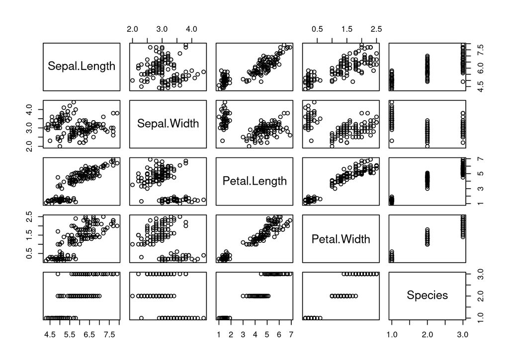

```r
plot(iris)
```

avec deux vecteurs, on écrit le nom des vecteur séparés par des virgules

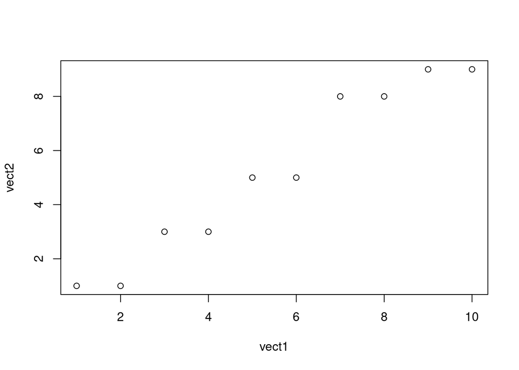

```r
vect1 <-  c(1,2,3,4,5,6,7,8,9,10)
vect2 <-  c(1,1,3,3,5,5,8,8,9,9)
plot(vect1,vect2)
```

Le package `ggplot2` permet de réaliser des graphiques plus complexes et mieux rendus. Je vous encourage chaudement à en apprendre les grands principes par vous même.

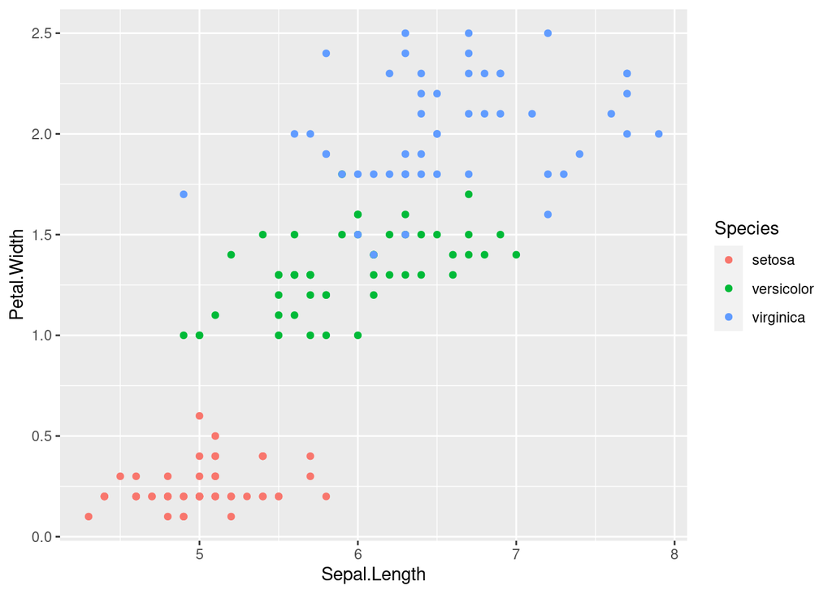

```r
library(ggplot2)
joli_plot <-  ggplot(iris)+
  geom_point( aes(x= Sepal.Length, y = Petal.Width, color=Species))
joli_plot
```

## 7.10 Combinaison de facteurs et tableaux de contingence

Lorqsqu’on dispose d’un jeu de données avec deux variable qualitatives, il est intéressant de combiner les deux variables et de réaliser un tableau de contingence , c’est à dire , compter les occurences (i.e. l’effectif) par combinaison de valeurs des modalités

ON utilise pour cela les fonction `table` .

Voici un exemple avec le jeu de données du package `palmerpenguins`

```r
library(palmerpenguins)
tab_conting <- table(penguins$species, penguins$island)
tab_conting
```

```
##
##             Biscoe Dream Torgersen
##   Adelie        44    56        52
##   Chinstrap      0    68         0
##   Gentoo       124     0         0
```

La fonction `prop .table` transforme un tableau de contingence en tableau de pourcentages :

```r
prop.table(tab_conting)
```

```
##
##                Biscoe     Dream Torgersen
##   Adelie    0.1279070 0.1627907 0.1511628
##   Chinstrap 0.0000000 0.1976744 0.0000000
##   Gentoo    0.3604651 0.0000000 0.0000000
```

## 7.11 Définir sa propre fonction

Une fonction se définit avec un nom, une affectation et le mot clé `function` . Les paramètres sont entre parenthèses, et le code de la fonction dans des accolades.

Le mot clé `return` est utilisé pour retourner le résultat de la fonction.

```r
my_func <-  function(p1, p2){
  return( p1*100 + p2)
}
my_func(4,6)
```

```
## [1] 406
```

```r
x <-  my_func(1,1)
x
```

```
## [1] 101
```

Pour être appelée, le code d’une fonction doit être exécuté une fois au préalable. Vous verrez ensuite la fonction apparaître dans votre environnement.

# 8 Lecture et Écriture de fichier CSV

Pour lire un fichier au format CSV, on utilise la fonction `read.csv`. Consultez la documentation pour plus de détails , notamment concernant les séparateurs(argument `sep`).

```r
pokedex <-  read.csv("./pokemons.csv", sep=",")
head(pokedex)
```

```
##   X.                  Name Type.1 Type.2 Total HP Attack Defense Sp..Atk
## 1  1             Bulbasaur  Grass Poison   318 45     49      49      65
## 2  2               Ivysaur  Grass Poison   405 60     62      63      80
## 3  3              Venusaur  Grass Poison   525 80     82      83     100
## 4  3 VenusaurMega Venusaur  Grass Poison   625 80    100     123     122
## 5  4            Charmander   Fire          309 39     52      43      60
## 6  5            Charmeleon   Fire          405 58     64      58      80
##   Sp..Def Speed Generation Legendary
## 1      65    45          1     False
## 2      80    60          1     False
## 3     100    80          1     False
## 4     120    80          1     False
## 5      50    65          1     False
## 6      65    80          1     False
```

### 8.0.1 Strings as factor

Par défaut , R considère que les variables chaînes de caractères sont des facteurs ce qui peut compliquer certains traitements. Il est fortement conseillée de désactiver cette option, en ajoutant l’argument `stringsAsFactors = FALSE` aux fonctions de lectures de fichiers tabulaires.

# 9 Exercice complet

- Récupérer le fichier `pokemons.csv` sur le répertoire partagée de la formation.
- Lire le fichier et le charger dans un dataframe
- Créer un second dataframe avec une sélection de deux types de pokemons (au choix)
- Calculer la moyenne et la médiane des points d’attaque et de défense de ces deux types de pokemons
- En vous inspirant d’un des deux codes ci-dessous , produisez un graphique qui affiche le niveau d’attaque en fonction du niveau de défense des pokemons sélectionnés, en distinguant les types de pokemons par la couleur.

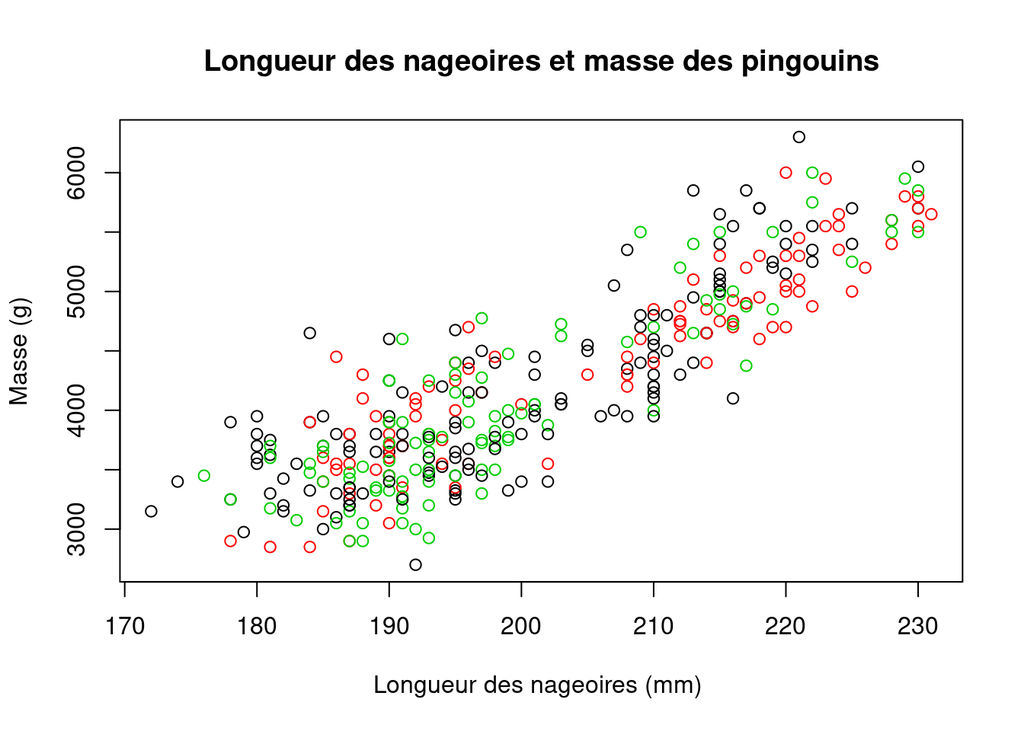

```r
library(palmerpenguins)
plot(x=penguins$flipper_length_mm, y=penguins$body_mass_g,
     col=iris$Species,
     main = "Longueur des nageoires et masse des pingouins",
     xlab="Longueur des nageoires (mm) ",
     ylab="Masse (g)")
```

Une version utilisant le package `ggplot2`

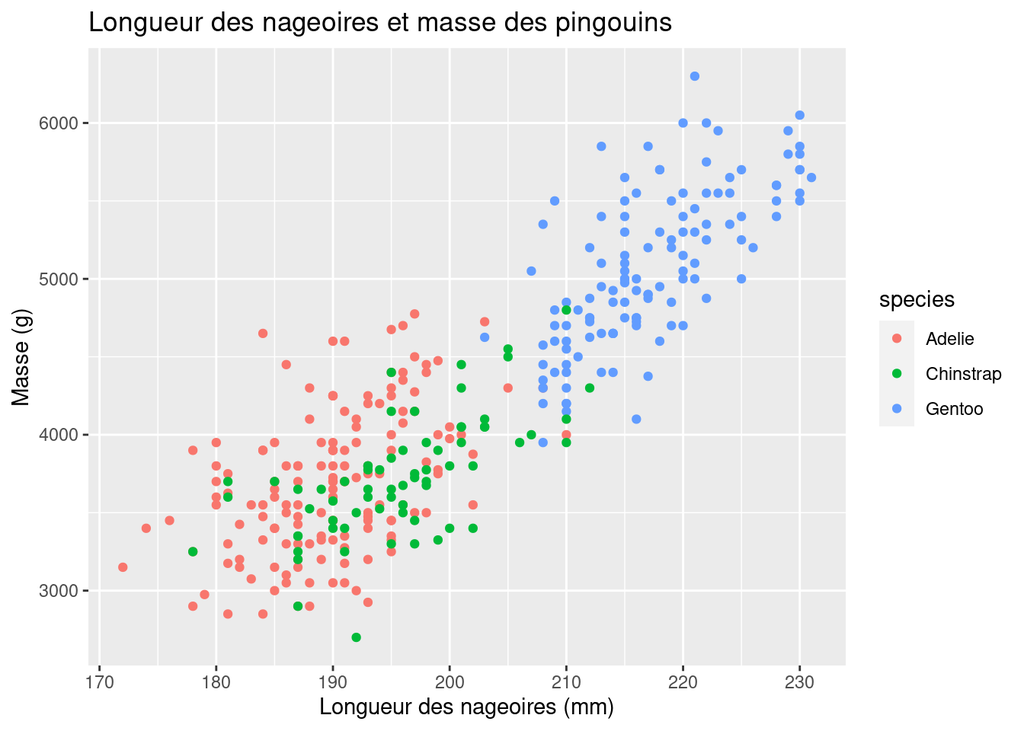

```r
library(palmerpenguins)
library(ggplot2)

 graph1 <-  ggplot(penguins)+
   geom_point(aes(x=flipper_length_mm, y=body_mass_g, color=species))+
   ggtitle("Longueur des nageoires et masse des pingouins")+
   xlab("Longueur des nageoires (mm)" )+
   ylab("Masse (g)")
graph1
```